# 3-avl-trees slides

## Trees: More Search Trees

[figure not shown]

#### Binary Search Trees

- Efficiency of the search, insertion, and deletion operations depend on the height of the tree.
  - Best case: $O(\log n)$
  - Worst case: $O(n)$
- One way is to recreate the tree every so often so that it remains balanced.
  - But that is expensive
- Ideally, we need a way to keep it balanced, *at runtime*

#### Binary Search Trees

- Create a binary tree with: 60, 12, 90, 4, 20, 80, 100
- Create a binary tree with: 100, 90, 80, 60, 20, 12, 4

#### Binary Search Trees

- Create a binary tree with: 60, 12, 90, 4, 20, 80, 100
- Create a binary tree with: 100, 90, 80, 60, 20, 12, 4

##### Order matters!

### AVL Tree

- Invented by G. M. __A__delson-__V__elskii and Y. M. __L__andis in 1962

### AVL Tree

- Invented by G. M. __A__delson-__V__elskii and Y. M. __L__andis in 1962
- Guarantees that the tree is height "balanced"
- A binary tree is *balanced* if the heights of the left and right subtrees of every node differ by at most 1. Examples:

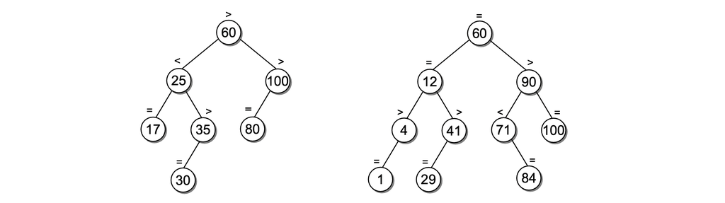

#### AVL Trees

- With each node in an AVL tree, we associate a **balance factor**, which indicates the height difference between the left and right branch.
  - *left high (>):* When the left subtree is higher than the right subtree.
  - *equal high (=):* When the two subtrees have equal height.
  - *right high (<):* When the right subtree is higher than the left subtree.

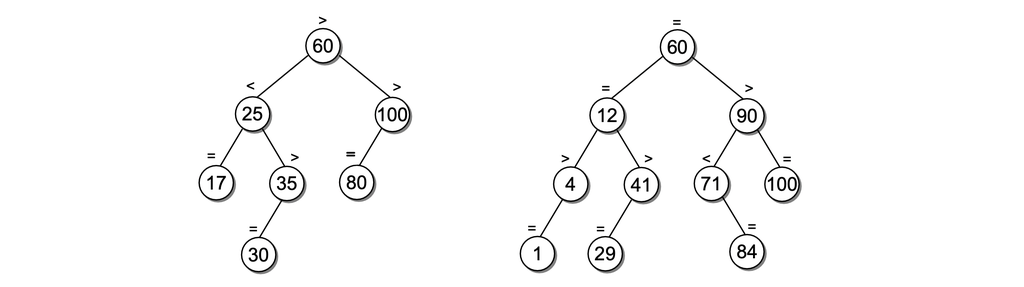

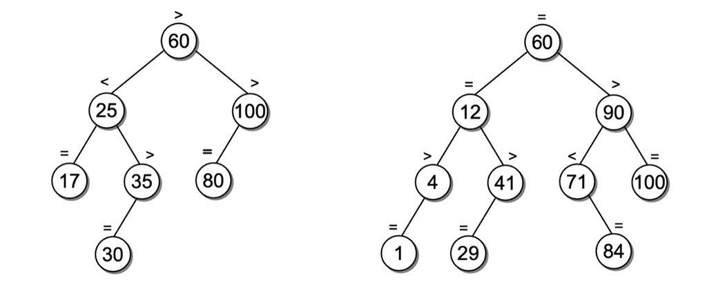

- How does the height of each node (subtree) change if we insert 40?
  - 10?
  - 28?
  - 32?

### Observation

##### The insertion of a new node changes the height of its ancestors by at most 1.

#### Search & Traversals in AVL

- Same as Binary Search Tree
- Difference: insertion and deletion done in a way that maintains the balance property.

#### Insertion

##### Insert 120

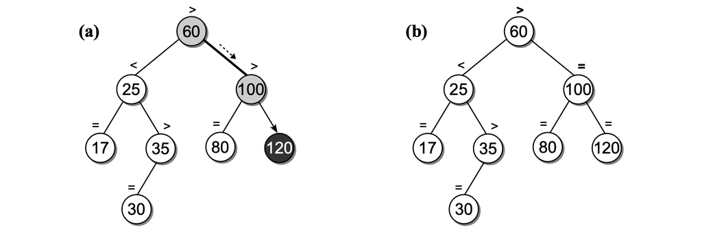

#### Insertion

##### Insert 28

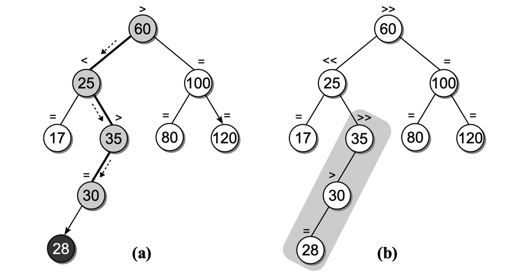

#### Insertion

##### Insert 28

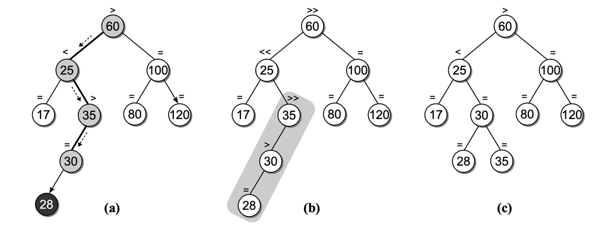

#### Insertions

##### After inserting a new key

- Multiple subtrees can become unbalanced along the insertion path.
- Only one (deepest and closest to the new node) will have to be rebalanced.

#### Insertions

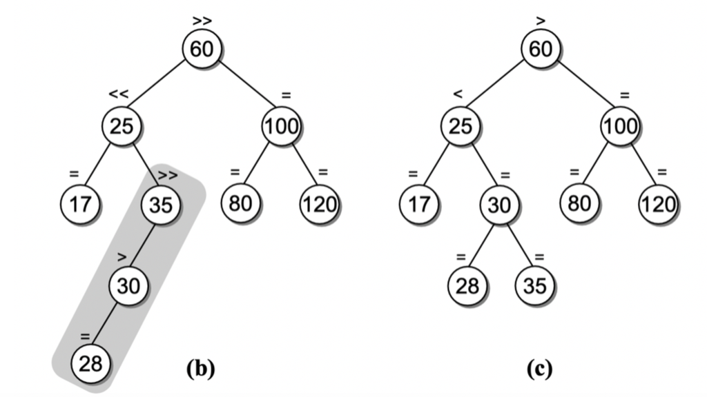

##### After inserting a new key

- After inserting the key, the balance factors  
  are adjusted (unwinding of the recursion).
- The first unbalanced subtree encountered  
  has to be rebalanced.
- The root of this subtree is known as  
  the **pivot** node.

##### Middle element becomes the root

#### Insertions

##### The same pattern could occur to the right

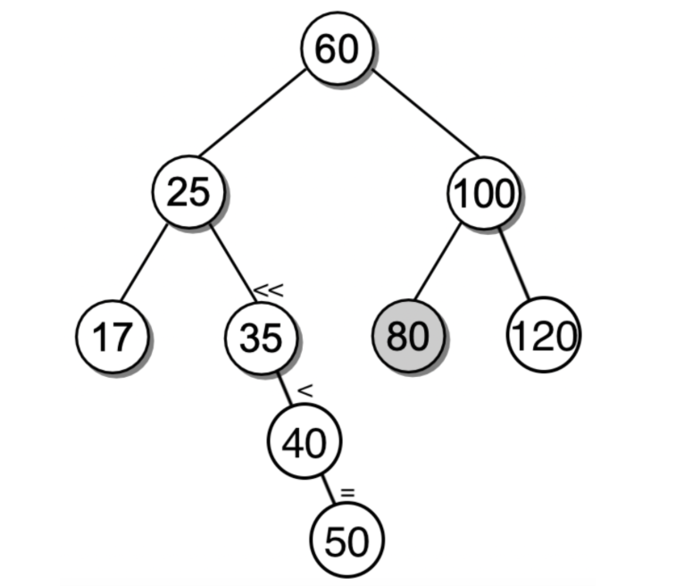

#### Insertions

##### ...and the same approach works

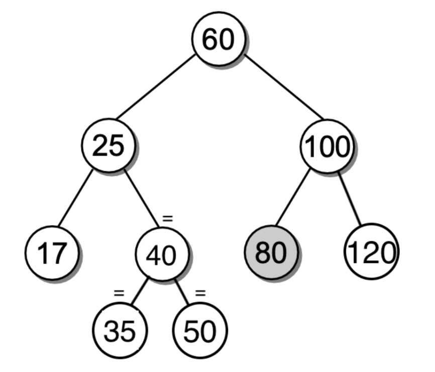

##### Middle element becomes the root

#### Rotations

- An AVL subtree is rebalanced by performing a **rotation** around the *pivot* node.
- This involves rearranging the links of the pivot node, its children, and possibly one of its grandchildren.
- The actual modifications depend on which descendant’s subtree of the pivot node the new key was inserted into and the balance factors.
- Four possible cases arise.

#### Rotation: 4 cases

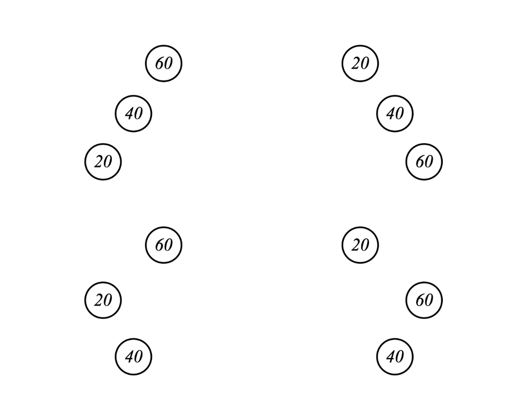

### How far up can the closest imbalanced node be?

#### How far up can the closest imbalanced node be?

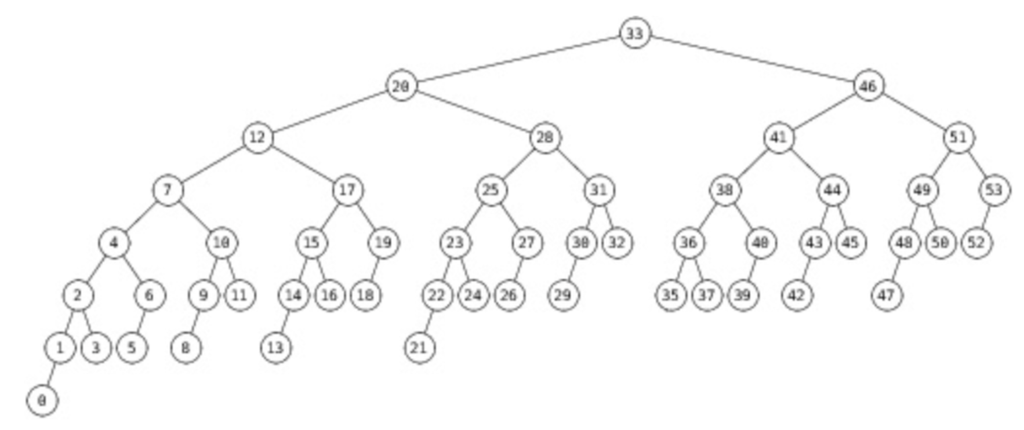

#### Rotation: Case 1 (detailed visual)

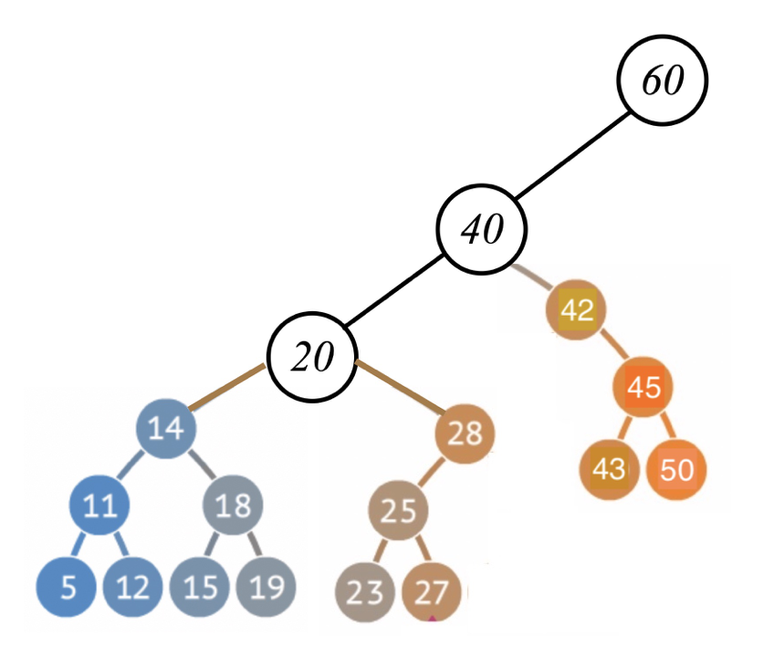

*Note: Figure does not show a complete balanced tree*.

- It just indicates that nodes such as 20, 40 and 60 may have non-empty subtrees.

### Rotations

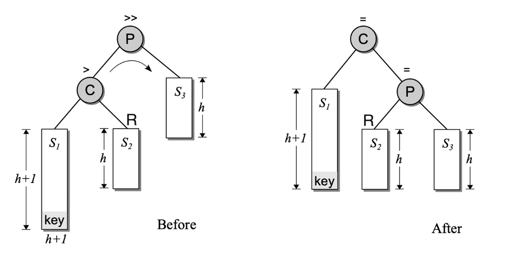

#### Balance before insertion

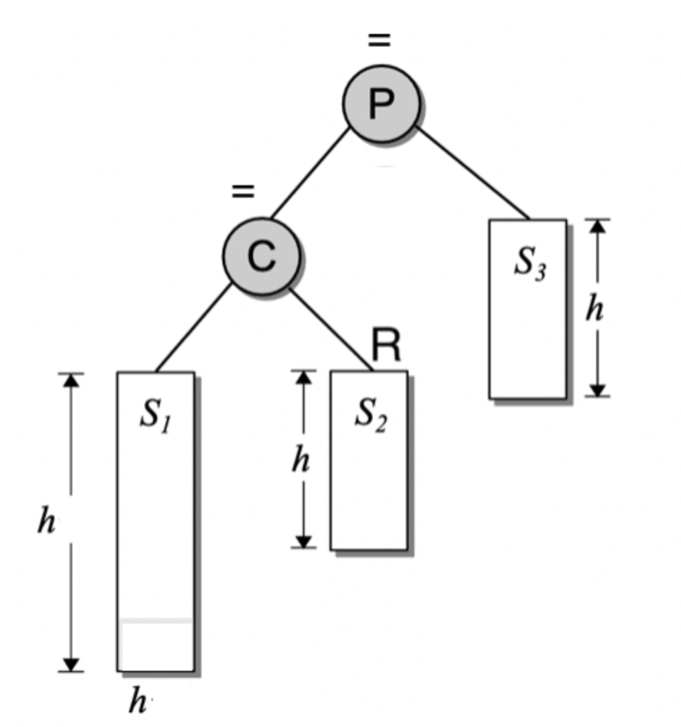

- Height of $S1$, $S2$ and $S3$ is $h$
- Height of $C$ is $(h+1)$
  - both children at $h$
- Height of $P$ is $(h+2)$
  - $S3$ at $h$, $C$ at $(h+1)$
  - difference of only one level

##### Height of $P$ is $(h + 2)$

#### Imbalance due to insertion

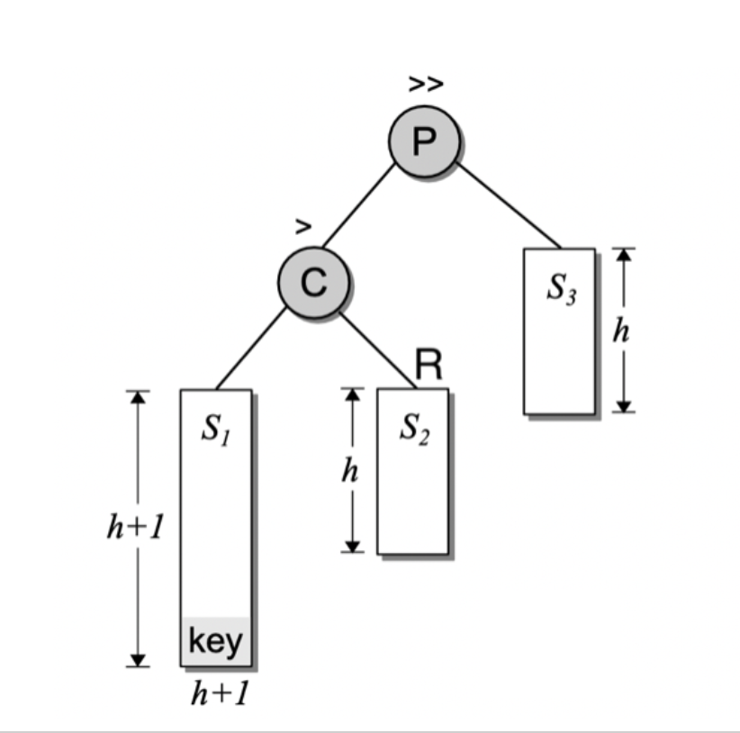

- Imbalance at $P$
- Height of $R$ must be $h$
  - if it was $(h-1),\ $ imbalance would have been at $C$.
  - if it was $(h+1),\ $ then $P$ would be unbalanced before insertion.
- Height of $C$ now is $(h+2)$
- Height of $P$ now is $(h+3)$
  - $P$'s left is $(h+2)$
  - right is $h$
  - $\implies$ imbalance at $P$!

##### Height of $P$ is now $(h+3)$

### Rotations

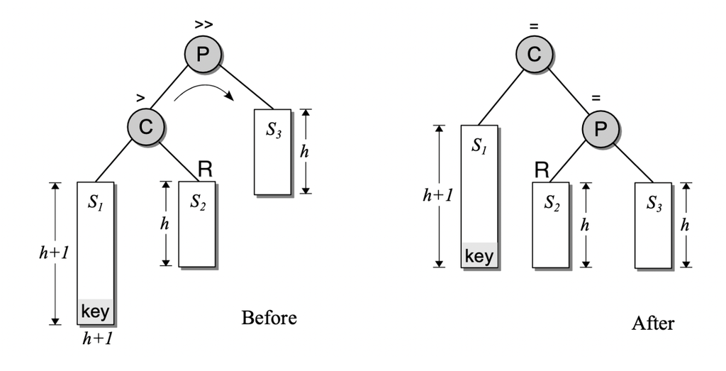

##### Case 1.

- Rebalance:
  - $P$ has to be rotated right over its left child $C$.
  - $P$ becomes the right child of $C$, and
  - $R$ right child of $C$ becomes the left child of $P$.

[figure not shown]

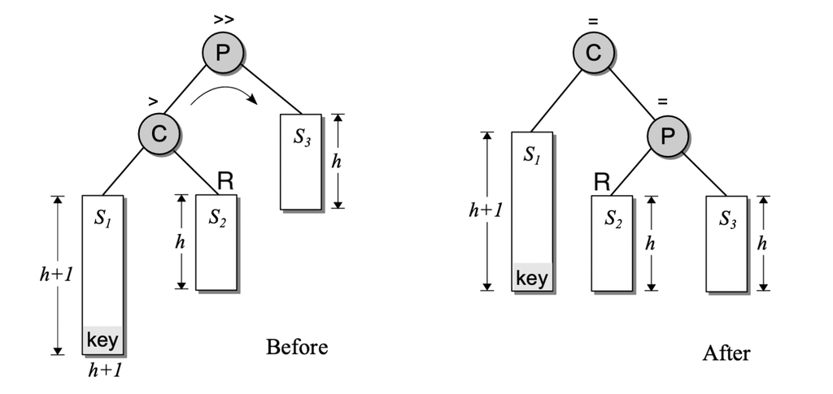

##### Height of unbalanced $P$ is $(h + 3)$

##### Height of balanced $C$ is $(h + 2)$

### Observation

##### We need not go any further up in the tree for rebalancing. (why?)

### Observation

##### We need not go any further up in the tree for rebalancing.

##### $\because$ The height of the modified subtree at the root $C$ (previously $P$) is unchanged.

### Rotations

##### Case 3. (symmetric to case 1)

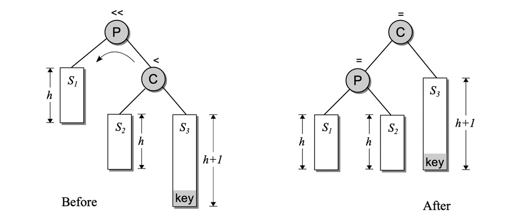

### Rotations

##### Case 2.

#### Balance before insertion at $S2$

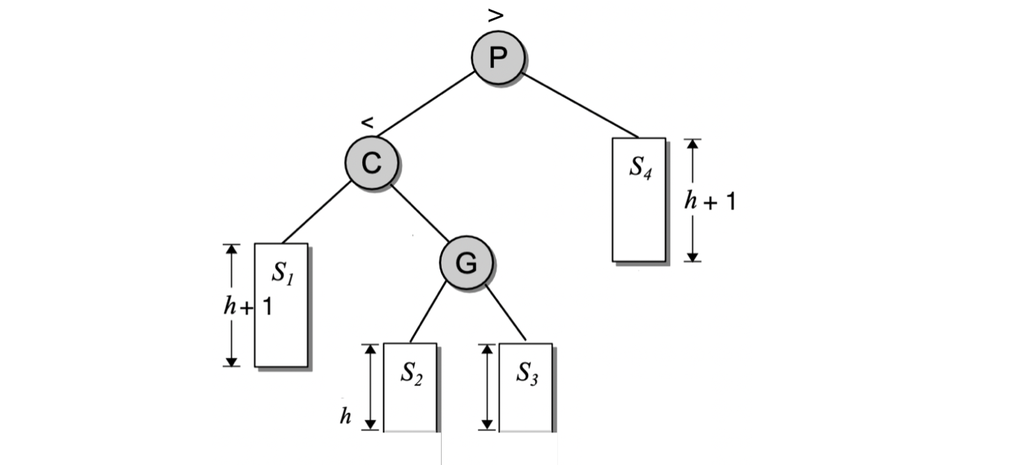

##### Find the heights of $S1, S2, S3, S4, G, C and P$

### Rotations

##### Case 2.

#### Imbalance after insertion at $S2$

##### $P$'s right subtree is at $(h+1)$ and left subtree at $(h+3)$

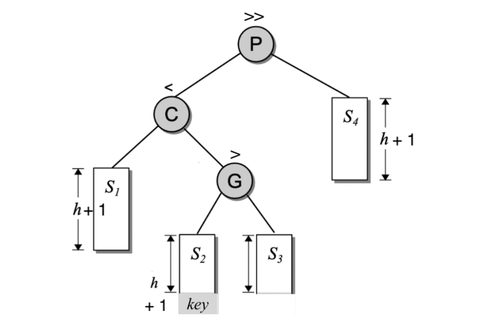

### Rotations

##### Case 2: Balance before insertion

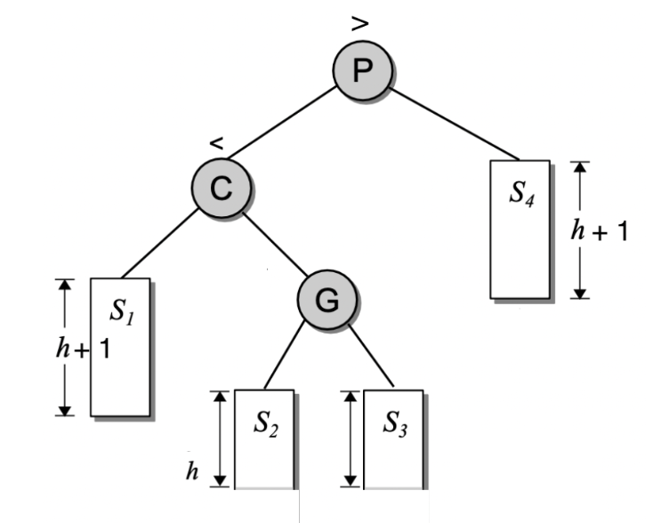

- Height of $S1$ and $S4$ is $h+1$
  - Height of $S4$ cannot be less than $h+1\ $ (why?)
    - if it was, then $P$ would have been  
      imbalanced to begin with  
      $C\ $ at $(h+2)$ and $S4$ at $h$.
  - Height of $S1$ cannot be less than $h+1\ $ (why?)
    - if it was, then after insertion $G$  
      whould be $(h+2)\ $ and $C$ would be imbalanced  
      (instead of $P$)

### Rotations

##### Case 2: Balance before insertion

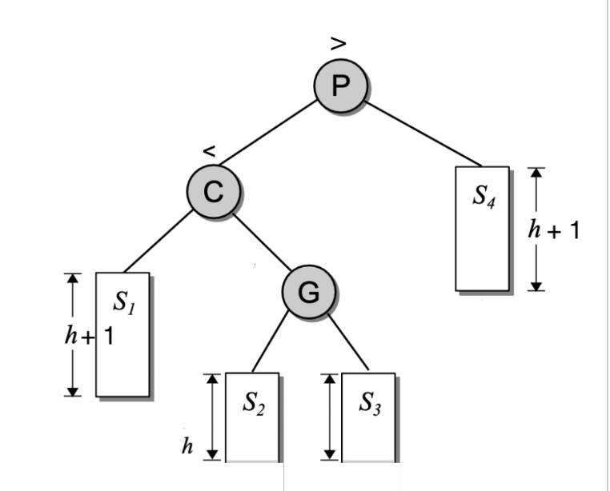

- Height of $S2\ $ and $S3\ $ is $h$
  - if $S3$ was $(h - 1),\ $ then the insertion at $S2$  
    would make $G$ unbalanced.
- Height of $C$ is $(h+2)$
  - both children at $h+1$
- Height of $P\ $ is $(h+3)$
  - $S4\ $ at $h+1,\ $ $C$ at $(h+2)$
  - difference of only one level

### Rotations

##### Case 2.

#### Imbalance after insertion at $S2$

[figure not shown]

##### $P$'s right subtree is at $(h+1)$ and left subtree at $(h+3)$

### Rotations

##### Case 2.

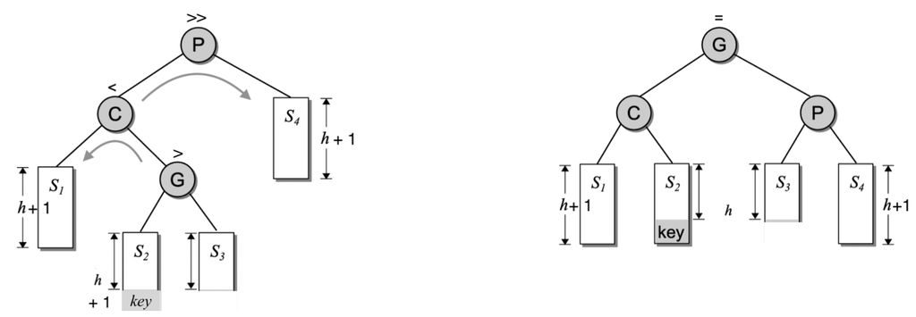

### Rotations

##### Case 2.

- Height of $P$ is $(h + 2)$
- Height of $C$ is $(h + 2)$
- $S3$ is now child of $P$

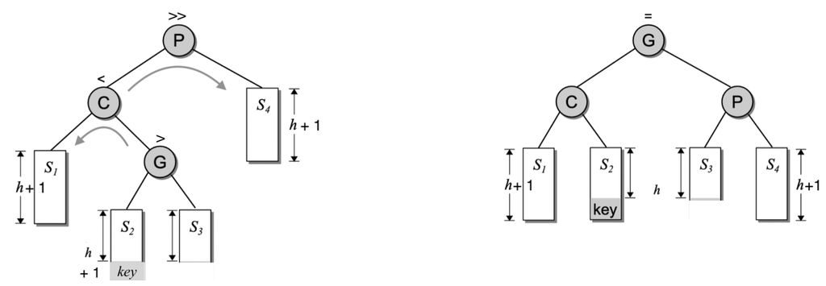

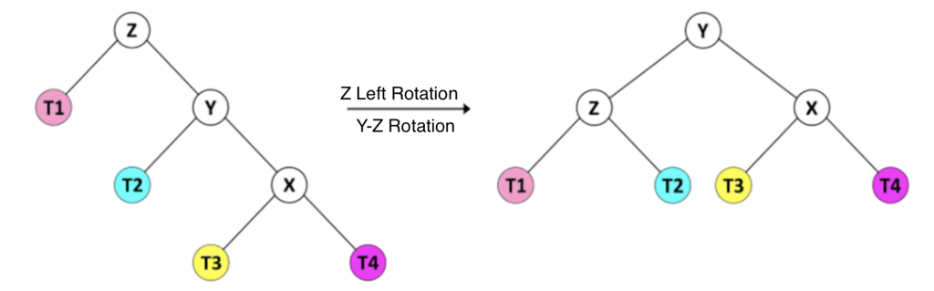

##### Calculate the initial and final heights of the roots

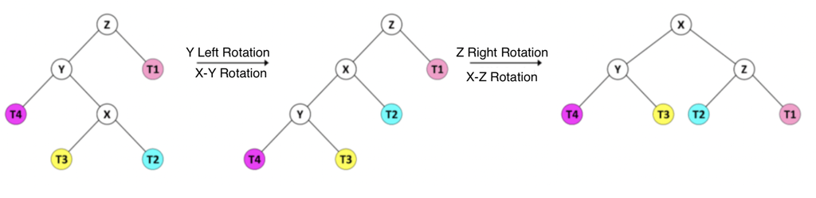

##### Calculate the initial and final heights of the roots

### Rotations

##### Case 4 (symmetric to case 2)

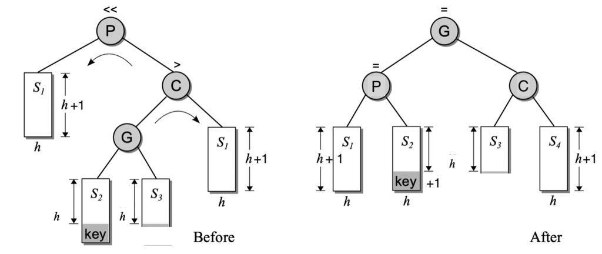

### Rotations

##### Cases 1 and 3 are solved by a single rotation

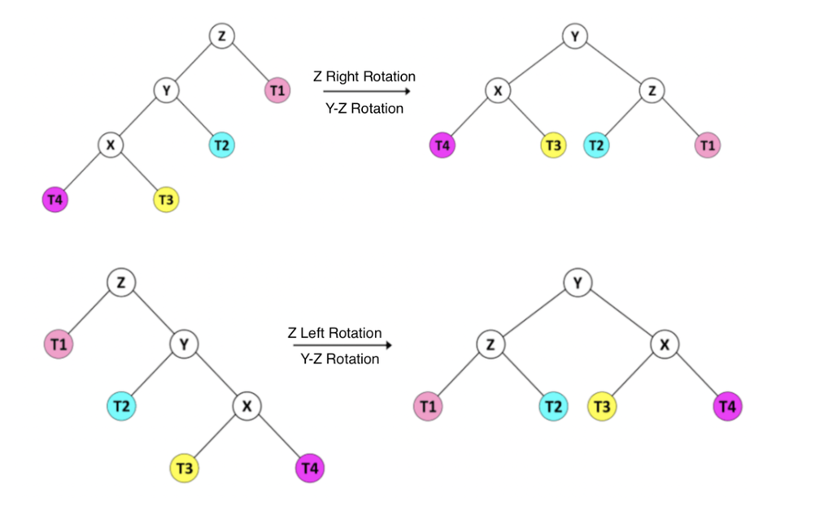

##### Middle element Y becomes the root

### Rotations

##### Cases 2 and 4 are solved by a double rotation

[figure not shown]

##### Middle element X becomes the root

### Binary Search Tree: Deletion

- Node is a leaf.
- Node has a single child.
  - single child became child of grandparent.
- Node has two children.
  - successor contents replaced the contentes of the deleted node
  - successor node got deleted

### Pause, Recap

### Observations

##### In a BST, the successor is a leaf or a node with only one (right) child (why?)

##### In an AVL tree, if a node has only one child, then that child is a leaf (why?)

### Observations

##### In a BST, the successor is a leaf or a node with only one (right) child

```
- If it did have a left child, that child would be the successor.
```

##### In an AVL tree, if a node has only one child, then that child is a leaf

```
- If that child is not a leaf, then the tree is unbalanced, and therefore not an AVL tree.
```

### Observations

##### In an AVL tree, we delete a leaf or its parent

```
- which is nearly the same thing, since
- the parent of a leaf, can be replaced by its child which becomes the leaf.
```

#### Deletion

An Example

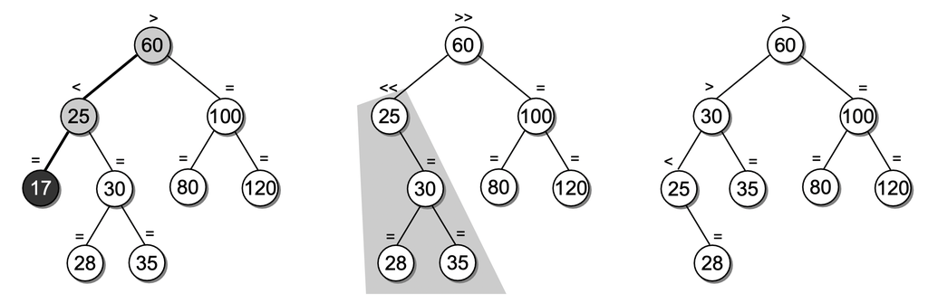

#### Deletion

[figure not shown]

##### Suppose deletion happens in $S4$

#### Deletion

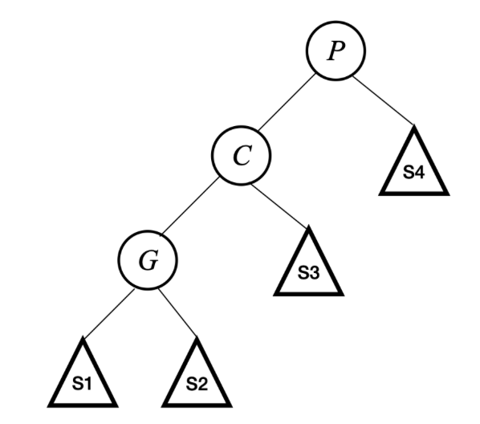

- Deletion happens in $S4$
  - Its height changes from $h$ to $(h-1)$
- Since $P$ was balanced before and is unbalanced now,
  - $P$ is at $(h+2)$
  - Height of $C$ is $(h+1)$
  - Therefore $G$ is at $h$
  - $S3$ is at $h\ $ or $(h-1)$
  - $S1\ $ and $S2\ $ at $(h-1)\ $ or $(h-2)$
    - at least one of them is at $(h-1)$.

#### Deletion

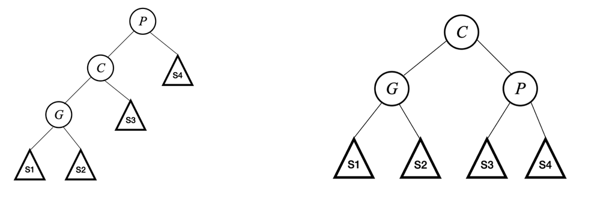

- $P$ is at $(h)$ or $(h+1)$
- $G$ is at $h$
- $C$ is at $(h+1)$ or $(h+2)$
- **(before) $P$ is at $(h+2)$**
- **(now) $C$ is at $(h+1)$ or $(h+2)$**